# Wildfire Prediction using Machine Learning

Building an Machine Learning model to predict wildfire intensity from a dataset of 50,000 wildfires in the US

Noman Bashir, Rudrapriya Bose, Chung Hsiang Cheng, Yinyu Kao, Emile Paris

# 1 Data Cleaning & Exploratory Data Analysis

The data is coming from [kaggle](https://www.kaggle.com/) and is a random sampling of 50’000 fires coming from [this dataset](https://www.kaggle.com/datasets/rtatman/188-million-us-wildfires) It has been combined with historical weather data related to the specific location of the different fires.

You can find the source of the data set [here](https://www.kaggle.com/datasets/capcloudcoder/us-wildfire-data-plus-other-attributes).

The first step is to take a look a the dataset in order to guide us for the cleaning.

Here is the structure of the dataset :

```
## 'data.frame':    55367 obs. of  43 variables:
##  $ X               : int  0 1 2 3 4 5 6 7 8 9 ...
##  $ Unnamed..0      : int  0 1 2 3 4 5 6 7 8 9 ...
##  $ fire_name       : chr  "" "" "" "WNA  1" ...
##  $ fire_size       : num  10 3 60 1 2 1 5.2 1 1 1 ...
##  $ fire_size_class : chr  "C" "B" "C" "B" ...
##  $ stat_cause_descr: chr  "Missing/Undefined" "Arson" "Arson" "Debris Burning" ...
##  $ latitude        : num  18.1 35 34.9 39.6 30.7 ...
##  $ longitude       : num  -66.8 -87.6 -88.7 -119.3 -90.6 ...
##  $ state           : chr  "PR" "TN" "MS" "NV" ...
##  $ disc_clean_date : chr  "2/11/2007" "12/11/2006" "2/29/2004" "6/6/2005" ...
##  $ cont_clean_date : chr  "" "" "" "6/6/2005" ...
##  $ discovery_month : chr  "Feb" "Dec" "Feb" "Jun" ...
##  $ disc_date_final : chr  "" "" "" "6/6/2005 2:14" ...
##  $ cont_date_final : chr  "" "" "" "6/6/2005 18:00" ...
```

[output cut: 29 more lines]

Number of rows :

```
## [1] 55367
```

## 1.1 Data Cleaning

First, we can remove the two first columns since they are not relevant for our analysis.

```r
wildfires <- wildfires[, -c(1, 2)]
```

We rare getting rid of the **missing data**.

```r
wildfires <- wildfires %>% filter(weather_file != "File Not Found")
```

For better visualization and data handling we are switching the time columns to **POSIXct**.

```r
wildfires <- wildfires %>%
  mutate(
    discovery_date =
      as.POSIXct(disc_clean_date, format = "%m/%d/%Y")
  )
wildfires$discovery_date
wildfires <- wildfires %>%
  mutate(
    discovery_time =
      as.POSIXct(disc_date_final, format = "%m/%d/%Y %H:%M")
  )
wildfires$discovery_time
wildfires <- wildfires %>%
  mutate(
    contained_time =
      as.POSIXct(cont_date_final, format = "%m/%d/%Y %H:%M")
  )
wildfires$contained_time

wildfires$putout_time <-
  difftime(wildfires$contained_time, wildfires$discovery_time, units = "mins")
wildfires$putout_time
```

we’ve now cleaned most of the data. While exploring it, we can observe that we don’t need *disc_clean_date*, *disc_date_final*, *cont_date_final*, *cont_clean_date*, *disc_date_pre*, *disc_pre_year* and *disc_pre_month* variables. And also the *wstation_usaf*, *wstation_byear*,*wstation_eyear* and *wstation_wban* since these are identifiers.

```r
wildfires_clean <- wildfires %>%
  select(-c(
    "disc_clean_date", "disc_date_final", "cont_date_final",
    "cont_clean_date", "disc_date_pre", "disc_pre_year", "disc_pre_month",
    "weather_file", "fire_mag", "wstation_usaf", "wstation_byear",
    "wstation_eyear", "wstation_wban"
  ))
```

Here’s the structure of the dataset after this first part of cleaning :

```
## 'data.frame':    41132 obs. of  31 variables:
##  $ fire_name       : chr  "" "" "" "WNA  1" ...
##  $ fire_size       : num  10 3 60 1 5.2 1 1 1 8.3 1 ...
##  $ fire_size_class : chr  "C" "B" "C" "B" ...
##  $ stat_cause_descr: chr  "Missing/Undefined" "Arson" "Arson" "Debris Burning" ...
##  $ latitude        : num  18.1 35 34.9 39.6 31.3 ...
##  $ longitude       : num  -66.8 -87.6 -88.7 -119.3 -83.4 ...
##  $ state           : chr  "PR" "TN" "MS" "NV" ...
##  $ discovery_month : chr  "Feb" "Dec" "Feb" "Jun" ...
##  $ putout_time     : 'difftime' num  NA NA NA 946 ...
##   ..- attr(*, "units")= chr "mins"
##  $ dstation_m      : num  58918 32665 105122 43433 42973 ...
##  $ Vegetation      : int  12 15 16 0 12 12 15 15 12 16 ...
##  $ Temp_pre_30     : num  24.48 7.55 4.97 16.28 14.88 ...
##  $ Temp_pre_15     : num  24.72 7.01 5.78 19 16.41 ...
```

[output cut: 18 more lines]

Number of rows :

```
## [1] 41132
```

## 1.2 Exploratory Data Analysis

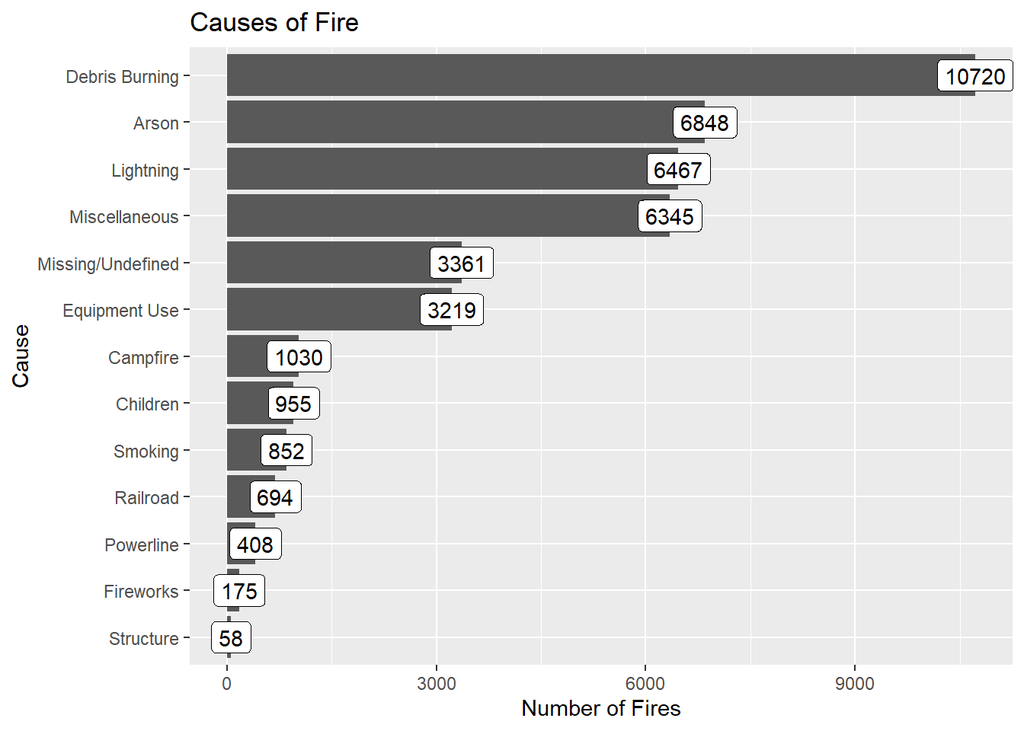

we can see that that there”s a lot of missing or undefined values. So, we should remove them

```r
wildfires_clean <- wildfires_clean %>%
  filter(stat_cause_descr != "Missing/Undefined")
```

There’s also only 58 “*Structure*” and 175 “*Fireworks*”. Maybe we should consider adding these to “*Misc*”, but let’s see if they are overrepresented in one single class type first.

which cause is predominant in each class?

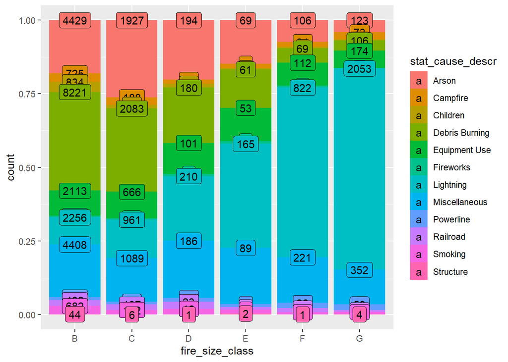

| fire_size_class | stat_cause_descr | n |
| --- | --- | --- |
| B | Arson | 4429 |
| B | Campfire | 725 |
| B | Children | 834 |
| B | Debris Burning | 8221 |
| B | Equipment Use | 2113 |
| B | Fireworks | 119 |
| B | Lightning | 2256 |
| B | Miscellaneous | 4408 |
| B | Powerline | 233 |
| B | Railroad | 492 |
| B | Smoking | 682 |
| B | Structure | 44 |
| C | Arson | 1927 |
| C | Campfire | 188 |
| C | Children | 90 |
| C | Debris Burning | 2083 |
| C | Equipment Use | 666 |
| C | Fireworks | 32 |
| C | Lightning | 961 |
| C | Miscellaneous | 1089 |
| C | Powerline | 72 |
| C | Railroad | 137 |
| C | Smoking | 112 |
| C | Structure | 6 |
| D | Arson | 194 |
| D | Campfire | 13 |
| D | Children | 12 |
| D | Debris Burning | 180 |
| D | Equipment Use | 101 |
| D | Fireworks | 7 |
| D | Lightning | 210 |
| D | Miscellaneous | 186 |
| D | Powerline | 13 |
| D | Railroad | 23 |
| D | Smoking | 18 |
| D | Structure | 1 |
| E | Arson | 69 |
| E | Campfire | 7 |
| E | Children | 2 |
| E | Debris Burning | 61 |
| E | Equipment Use | 53 |
| E | Fireworks | 4 |
| E | Lightning | 165 |
| E | Miscellaneous | 89 |
| E | Powerline | 5 |
| E | Railroad | 4 |
| E | Smoking | 6 |
| E | Structure | 2 |
| F | Arson | 106 |
| F | Campfire | 24 |
| F | Children | 7 |
| F | Debris Burning | 69 |
| F | Equipment Use | 112 |
| F | Fireworks | 8 |
| F | Lightning | 822 |
| F | Miscellaneous | 221 |
| F | Powerline | 26 |
| F | Railroad | 19 |
| F | Smoking | 11 |
| F | Structure | 1 |
| G | Arson | 123 |
| G | Campfire | 73 |
| G | Children | 10 |
| G | Debris Burning | 106 |
| G | Equipment Use | 174 |
| G | Fireworks | 5 |
| G | Lightning | 2053 |
| G | Miscellaneous | 352 |
| G | Powerline | 59 |
| G | Railroad | 19 |
| G | Smoking | 23 |
| G | Structure | 4 |

*fireworks* and *structure* clearly are not overrepresented anywhere. This means they can be added to *misc* category

```r
wildfires_clean["stat_cause_descr"][wildfires_clean["stat_cause_descr"] == "Fireworks" | wildfires_clean["stat_cause_descr"] == "Structure"] <- "Miscellaneous"
```

let’s plot the count of wildfires over months :

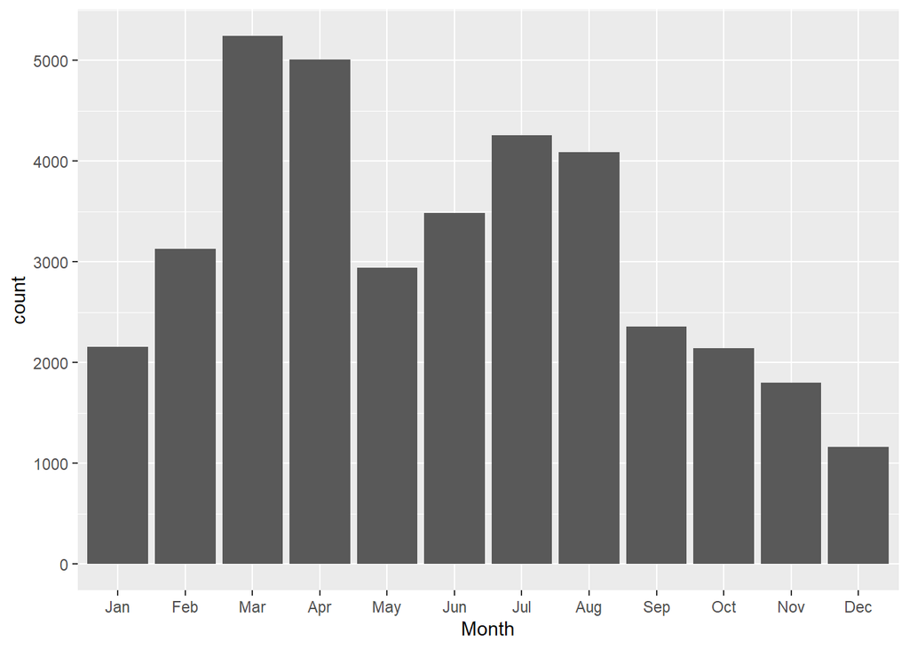

Now, we are going to look at:

- **wildfire size**

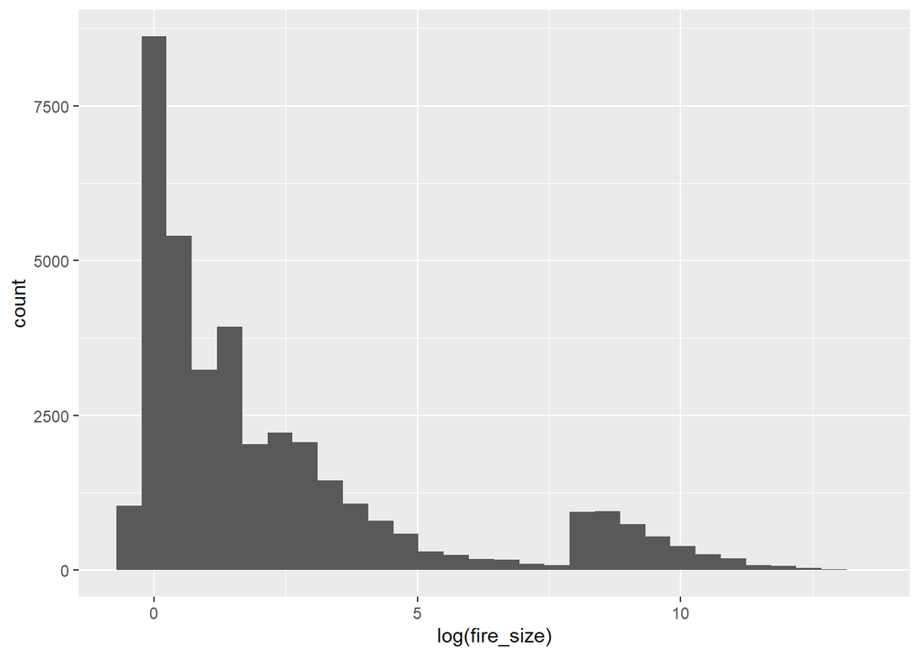

- **duration** (or putout time)

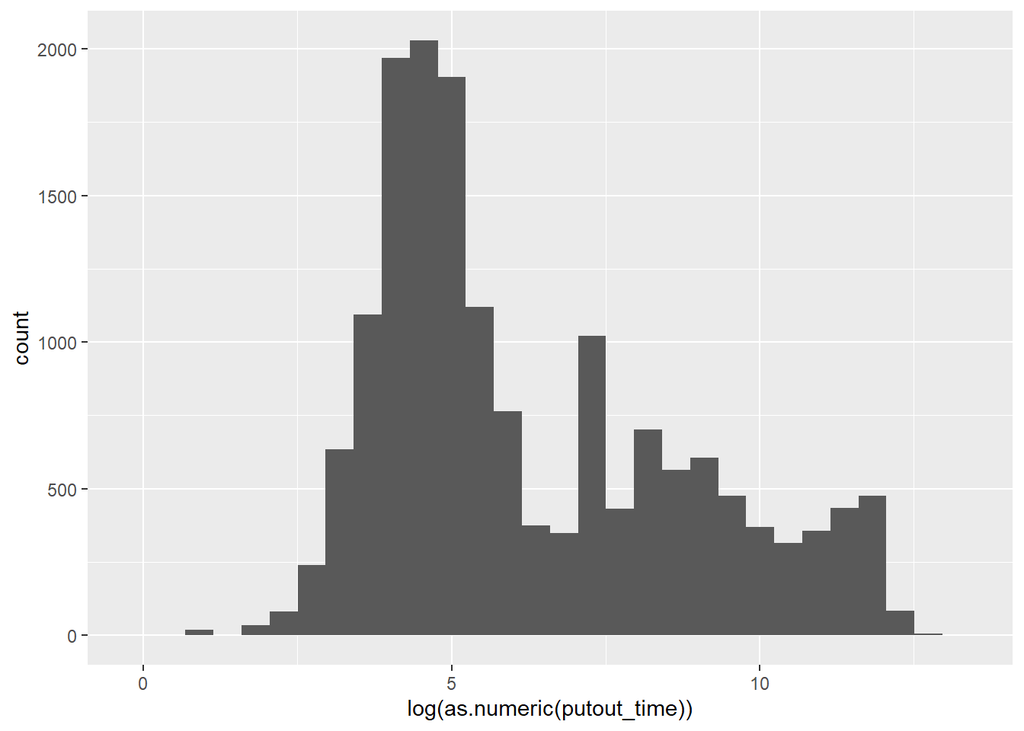

- boxplots of **fires per month**

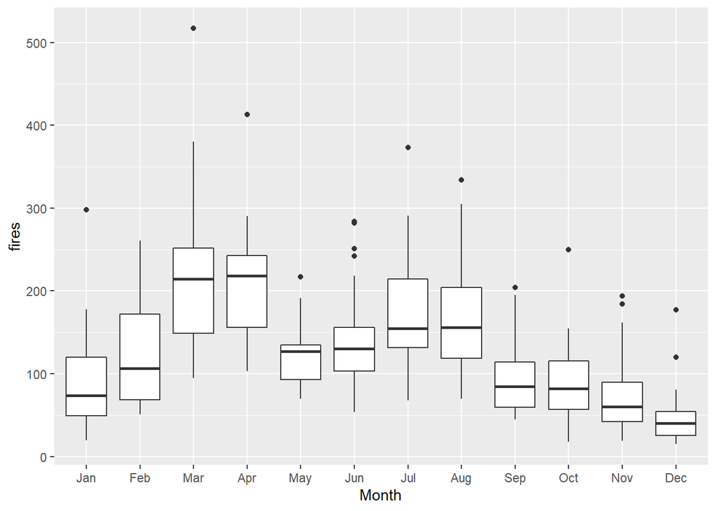

Let’s see if cause has any correlation with area burnt

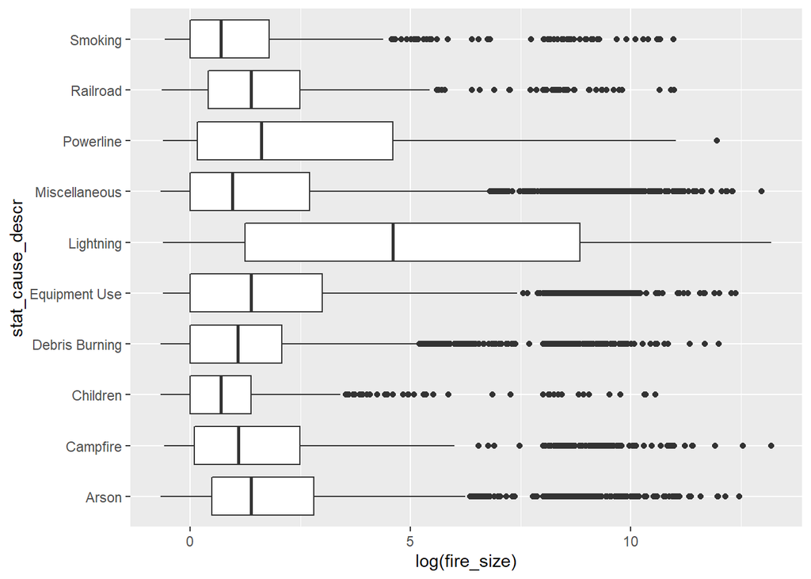

*lightning* clearly burns more on average

- checking if there is any noteworthy insight in **vegetation** and **fire-size**

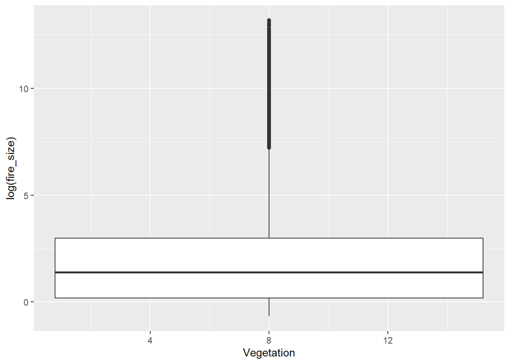

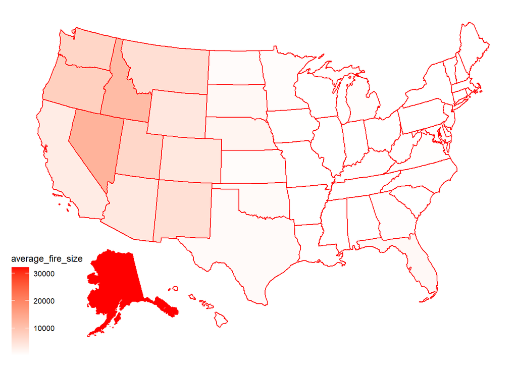

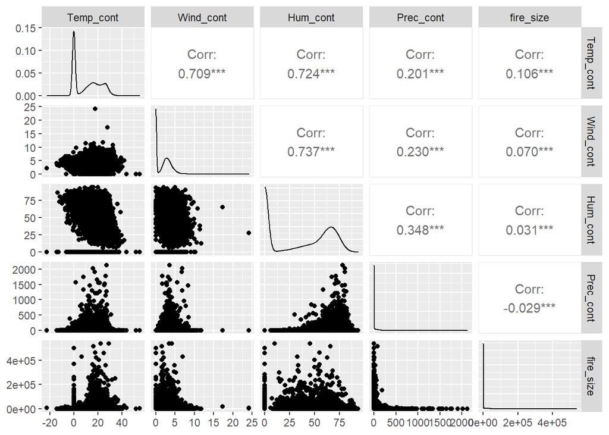

- The **full map** of all fires

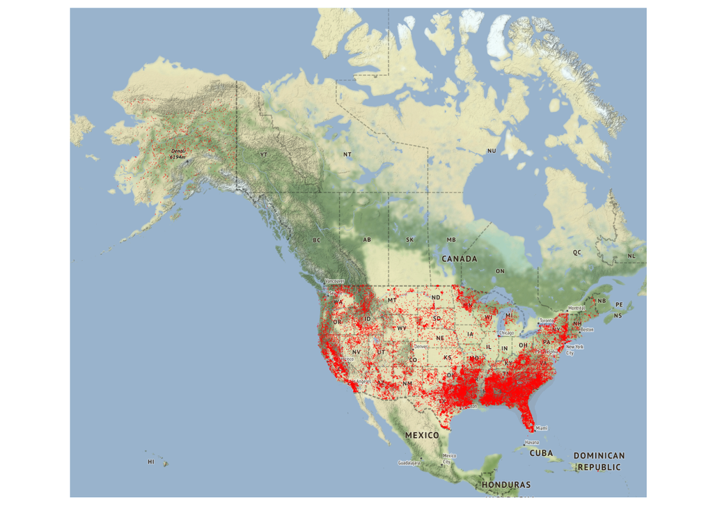

# 2 Classification

Now that we’ve done a basic analysis of the data, let’s move onto our classification task: **predicting the class of a fire**. To remind ourselves that this is an unbalanced subset, let’s take a quick look at the spread of classes in our set.

```
##  [1] "fire_name"        "fire_size"        "fire_size_class"  "stat_cause_descr"
##  [5] "latitude"         "longitude"        "state"            "discovery_month"
##  [9] "putout_time"      "dstation_m"       "Vegetation"       "Temp_pre_30"
## [13] "Temp_pre_15"      "Temp_pre_7"       "Temp_cont"        "Wind_pre_30"
## [17] "Wind_pre_15"      "Wind_pre_7"       "Wind_cont"        "Hum_pre_30"
## [21] "Hum_pre_15"       "Hum_pre_7"        "Hum_cont"         "Prec_pre_30"
## [25] "Prec_pre_15"      "Prec_pre_7"       "Prec_cont"        "remoteness"
## [29] "discovery_date"   "discovery_time"   "contained_time"
```

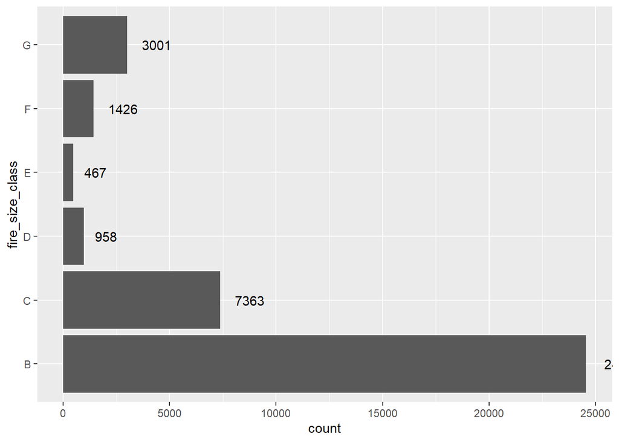

We can see that there is a clear mismatch in classes. There are two options, **subsampling** and **resampling**. Since there’s a lot of data available, we will subsample to go down to 467

## 2.1 subsample

we don’t need a lot of the columns in *wildfires_clean* when doing classification, so we will remove them, and mutate some columns as well

```r
wildfires_classification <- wildfires_clean %>% select(!c(fire_name, fire_size, latitude, longitude, putout_time, discovery_time, discovery_date, contained_time))
```

There are a lot of features that may be correlated (such as temperature across days).We will try and reduce dimensions by using **PCA** to select only the most valuable features.

```
##  [1] "fire_size_class"  "stat_cause_descr" "state"            "discovery_month"
##  [5] "dstation_m"       "Vegetation"       "Temp_pre_30"      "Temp_pre_15"
##  [9] "Temp_pre_7"       "Temp_cont"        "Wind_pre_30"      "Wind_pre_15"
## [13] "Wind_pre_7"       "Wind_cont"        "Hum_pre_30"       "Hum_pre_15"
## [17] "Hum_pre_7"        "Hum_cont"         "Prec_pre_30"      "Prec_pre_15"
## [21] "Prec_pre_7"       "Prec_cont"        "remoteness"
```

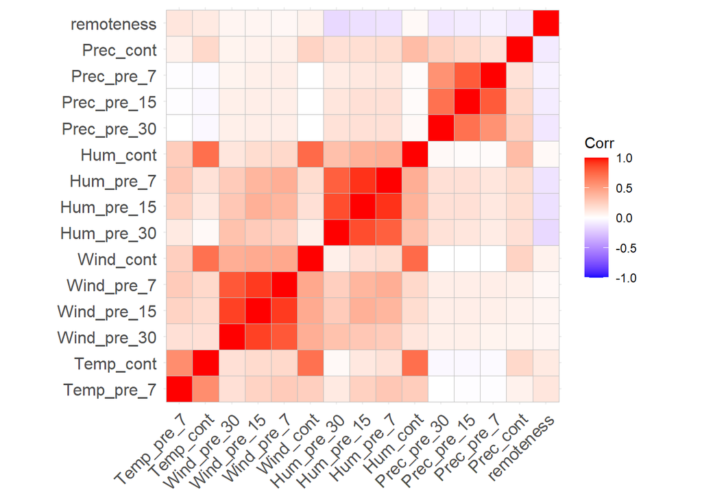

There’s a fair bit of correlation between the temperature indicators, it might be worthwhile to remove them

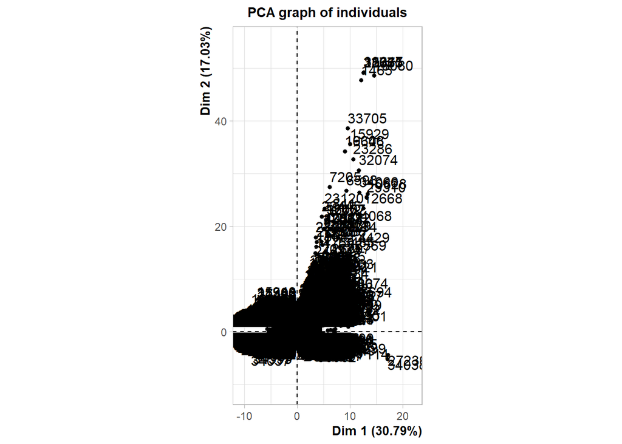

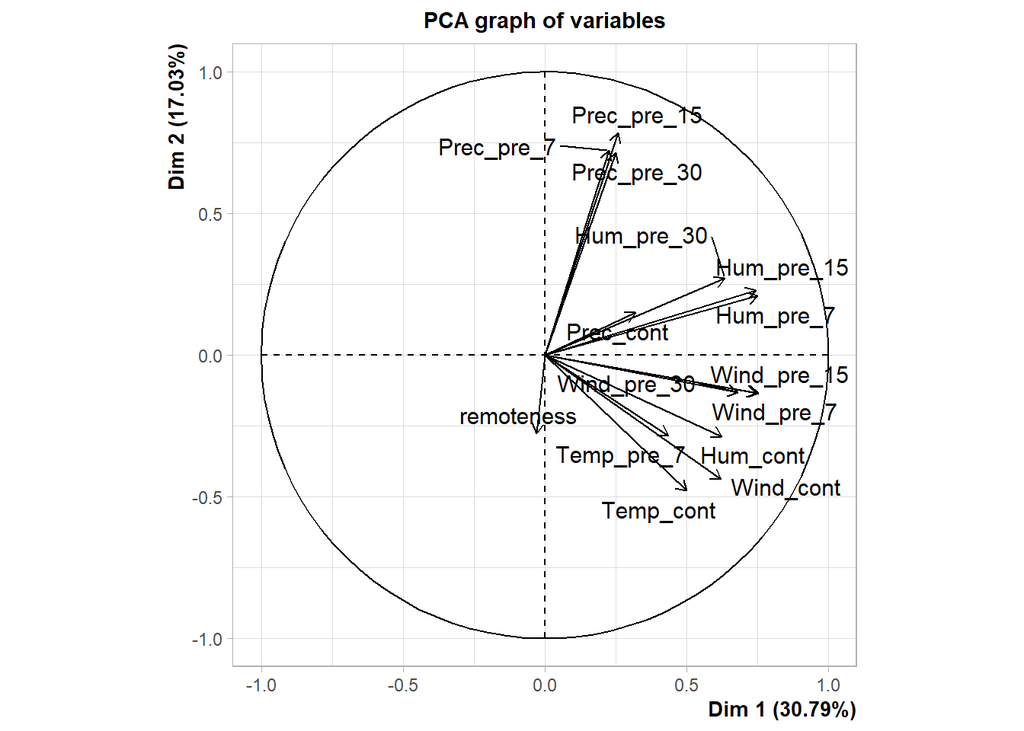

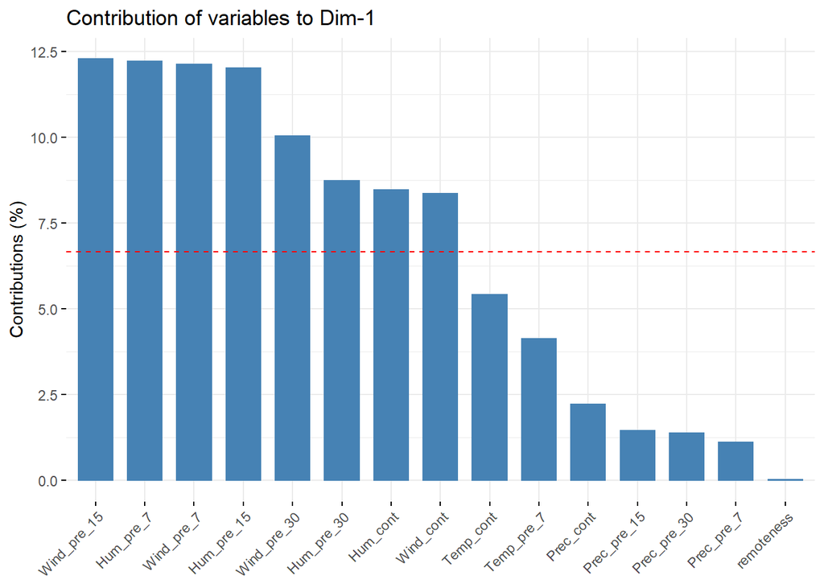

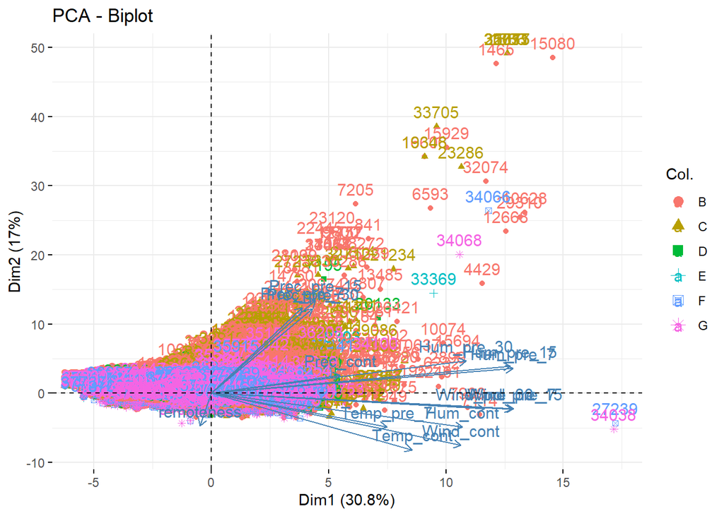

from the plot, we can see *wind_pre_15*, *hum_pre_7* and *temp_cont* are better predictors. We can remove the other variables of temperature for ease of statistical techniques

```
##  [1] "fire_size_class"  "stat_cause_descr" "state"            "discovery_month"
##  [5] "dstation_m"       "Vegetation"       "Temp_cont"        "Wind_pre_15"
##  [9] "Hum_pre_7"        "Prec_cont"        "remoteness"
```

Now let’s divide into training and test sets and subsample

```r
index.tr <- createDataPartition(y = wildfires_final$fire_size_class, p = 0.8, list = FALSE)
data.tr <- wildfires_final[index.tr, ]
data.te <- wildfires_final[-index.tr, ]
```

```r
classBs <- data.tr %>% filter(fire_size_class == "B")
classCs <- data.tr %>% filter(fire_size_class == "C")
classDs <- data.tr %>% filter(fire_size_class == "D")
classEs <- data.tr %>% filter(fire_size_class == "E")
classFs <- data.tr %>% filter(fire_size_class == "F")
classGs <- data.tr %>% filter(fire_size_class == "G")

rows <- c(nrow(classBs), nrow(classCs), nrow(classDs), nrow(classEs), nrow(classFs), nrow(classGs))
minrows <- min(rows)

indexB <- sample(nrow(classBs), size = minrows, replace = FALSE)
indexC <- sample(nrow(classCs), size = minrows, replace = FALSE)
indexD <- sample(nrow(classDs), size = minrows, replace = FALSE)
indexF <- sample(nrow(classEs), size = minrows, replace = FALSE)
indexG <- sample(nrow(classFs), size = minrows, replace = FALSE)

subsampled <- data.frame(rbind(classEs, classBs[indexB, ], classCs[indexC, ], classDs[indexD, ], classFs[indexF, ], classGs[indexG, ]))
```

## 2.2 KNN

To use knn, we need to create **dummy variables** for state, vegetation and month.

```r
y <- wildfires_final$fire_size_class
wildfires_final.comp <- wildfires_final %>% select(!fire_size_class)
wildfires_final.num <- wildfires_final.comp %>%
  select(where(is.numeric)) %>%
  scale() %>%
  as.data.frame()

wildfires_final.dumm <- wildfires_final.comp %>%
  select(!where(is.numeric)) %>%
  dummy_cols(remove_first_dummy = FALSE, remove_selected_columns = TRUE)
wildfires_final.dat <- data.frame(wildfires_final.num, wildfires_final.dumm)
wildfires_final.dat$fire_size_class <- y
```

Then we recreate a subsampling for the KNN method

```r
index.tr.knn <- createDataPartition(y = wildfires_final.dat$fire_size_class, p = 0.8, list = FALSE)
data.tr.knn <- wildfires_final.dat[index.tr.knn, ]
data.te.knn <- wildfires_final.dat[-index.tr.knn, ]
```

Now, we will subsample for this dummy version

```r
classBs.knn <- data.tr.knn %>% filter(fire_size_class == "B")
classCs.knn <- data.tr.knn %>% filter(fire_size_class == "C")
classDs.knn <- data.tr.knn %>% filter(fire_size_class == "D")
classEs.knn <- data.tr.knn %>% filter(fire_size_class == "E")
classFs.knn <- data.tr.knn %>% filter(fire_size_class == "F")
classGs.knn <- data.tr.knn %>% filter(fire_size_class == "G")

rows.knn <- c(nrow(classBs.knn), nrow(classCs.knn), nrow(classDs.knn), nrow(classEs.knn), nrow(classFs.knn), nrow(classGs.knn))
minrows.knn <- min(rows.knn)

indexB.knn <- sample(nrow(classBs.knn), size = minrows, replace = FALSE)
indexC.knn <- sample(nrow(classCs.knn), size = minrows, replace = FALSE)
indexD.knn <- sample(nrow(classDs.knn), size = minrows, replace = FALSE)
indexF.knn <- sample(nrow(classEs.knn), size = minrows, replace = FALSE)
indexG.knn <- sample(nrow(classFs.knn), size = minrows, replace = FALSE)

subsampled.knn <- data.frame(rbind(classEs.knn, classBs.knn[indexB.knn, ], classCs.knn[indexC.knn, ], classDs.knn[indexD.knn, ], classFs.knn[indexF.knn, ], classGs.knn[indexG.knn, ]))
```

Let’s run the model :

```r
mod.knn <- knn3(data = subsampled.knn, fire_size_class ~ ., k = 4)
predict.knn <- predict(mod.knn, newdata = data.te.knn, type = "prob")
fire_size_pred.knn <- colnames(predict.knn)[max.col(predict.knn, ties.method = "random")]

confusionMatrix(as.factor(fire_size_pred.knn), as.factor(data.te.knn$fire_size_class))
```

```
## Confusion Matrix and Statistics
##
##           Reference
## Prediction    B    C    D    E    F    G
##          B 1552  310   29    9   13   17
##          C 1370  454   40   18    9   12
##          D  939  311   48   16   26   34
##          E  654  282   46   30   40   36
##          F  297   88   15   15   74  126
##          G   99   27   13    5  123  375
##
## Overall Statistics
##
##                Accuracy : 0.3354
##                  95% CI : (0.3248, 0.3462)
##     No Information Rate : 0.6503
##     P-Value [Acc > NIR] : 1
##
##                   Kappa : 0.1352
##
##  Mcnemar's Test P-Value : <2e-16
##
## Statistics by Class:
##
##                      Class: B Class: C Class: D Class: E Class: F Class: G
## Sensitivity            0.3160  0.30842 0.251309 0.322581 0.259649  0.62500
## Specificity            0.8569  0.76168 0.819861 0.858158 0.925554  0.96159
## Pos Pred Value         0.8041  0.23857 0.034934 0.027574 0.120325  0.58411
## Neg Pred Value         0.4025  0.81979 0.976853 0.990254 0.969583  0.96744
## Prevalence             0.6503  0.19492 0.025291 0.012315 0.037738  0.07945
## Detection Rate         0.2055  0.06012 0.006356 0.003972 0.009799  0.04966
## Detection Prevalence   0.2556  0.25199 0.181939 0.144068 0.081435  0.08501
## Balanced Accuracy      0.5864  0.53505 0.535585 0.590369 0.592601  0.79330
```

It is a pretty poor accuracy. We can notice that **specificity** is high (i.e. negatives are detected well but sensitivity is low). So, it is time to train using CV.

```r
trctrl <- trainControl(method = "cv", number = 10)
trgrid <- expand.grid(k = seq(from = 1, to = 15, by = 1))

mod.knn.cv <- train(fire_size_class ~ ., data = subsampled.knn, method = "knn", metric = "Accuracy", tuneGrid = trgrid, trControl = trctrl)

final.knn <- knn3(data = subsampled.knn, fire_size_class ~ ., k = mod.knn.cv$bestTune)
final.predict.knn <- predict(final.knn, newdata = data.te.knn, type = "prob")
fire_size_pred.knn <- colnames(final.predict.knn)[max.col(predict.knn, ties.method = "random")]

confusionMatrix(as.factor(fire_size_pred.knn), as.factor(data.te.knn$fire_size_class))
```

```
## Confusion Matrix and Statistics
##
##           Reference
## Prediction    B    C    D    E    F    G
##          B 1565  309   29    8   11   13
##          C 1355  451   41   15    8   15
##          D  955  319   49   17   24   32
##          E  666  279   43   33   38   34
##          F  282   86   17   13   69  125
##          G   88   28   12    7  135  381
##
## Overall Statistics
##
##                Accuracy : 0.3374
##                  95% CI : (0.3267, 0.3482)
##     No Information Rate : 0.6503
##     P-Value [Acc > NIR] : 1
##
##                   Kappa : 0.1378
##
##  Mcnemar's Test P-Value : <2e-16
##
## Statistics by Class:
##
##                      Class: B Class: C Class: D Class: E Class: F Class: G
## Sensitivity            0.3187  0.30639 0.256545  0.35484 0.242105  0.63500
## Specificity            0.8599  0.76414 0.817009  0.85789 0.928031  0.96116
## Pos Pred Value         0.8088  0.23926 0.035100  0.03019 0.116554  0.58525
## Neg Pred Value         0.4043  0.81983 0.976933  0.99071 0.968966  0.96827
## Prevalence             0.6503  0.19492 0.025291  0.01231 0.037738  0.07945
## Detection Rate         0.2072  0.05972 0.006488  0.00437 0.009137  0.05045
## Detection Prevalence   0.2562  0.24960 0.184852  0.14473 0.078390  0.08620
## Balanced Accuracy      0.5893  0.53527 0.536777  0.60636 0.585068  0.79808
```

The accuracy is still low, it is time to try other models.

## 2.3 Neural Networks

After KNN the next model is the neural network. Let’s run the model and analyse the outcome :

```
## Confusion Matrix and Statistics
##
##           Reference
## Prediction    B    C    D    E    F    G
##          B 1841  560   75   36   21   14
##          C 1308  370   50   31   20   23
##          D  176   60    7    5    5    3
##          E 1360  412   52   19   48   92
##          F  220   65    6    2   43   76
##          G    6    5    1    0  148  392
##
## Overall Statistics
##
##                Accuracy : 0.3538
##                  95% CI : (0.343, 0.3647)
##     No Information Rate : 0.6503
##     P-Value [Acc > NIR] : 1
##
##                   Kappa : 0.1053
##
##  Mcnemar's Test P-Value : <2e-16
##
## Statistics by Class:
##
##                      Class: B Class: C  Class: D Class: E Class: F Class: G
## Sensitivity            0.3749  0.25136 0.0366492 0.204301 0.150877  0.65333
## Specificity            0.7327  0.76447 0.9661731 0.736694 0.949223  0.97699
## Pos Pred Value         0.7228  0.20533 0.0273438 0.009581 0.104369  0.71014
## Neg Pred Value         0.3866  0.80835 0.9747807 0.986712 0.966106  0.97029
## Prevalence             0.6503  0.19492 0.0252913 0.012315 0.037738  0.07945
## Detection Rate         0.2438  0.04899 0.0009269 0.002516 0.005694  0.05191
## Detection Prevalence   0.3373  0.23861 0.0338983 0.262579 0.054555  0.07309
## Balanced Accuracy      0.5538  0.50792 0.5014111 0.470498 0.550050  0.81516
```

In this case also the result is a **low accuracy**. It clearly means that neural networks are not very good at predicting

## 2.4 Random Forests

```r
mod.rf <- randomForest::randomForest(as.factor(fire_size_class) ~ ., data = subsampled.knn, ntree = 1000, importance = TRUE)
pred.rf <- predict(mod.rf, newdata = data.te.knn)
```

```r
confusionMatrix(as.factor(pred.rf), as.factor(data.te$fire_size_class))
```

```
## Confusion Matrix and Statistics
##
##           Reference
## Prediction    B    C    D    E    F    G
##          B 1814  528   61   32   20   33
##          C 1431  430   63   37   19   21
##          D  641  194   28   11   15   24
##          E  651  210   25    9   23   47
##          F  308   84   12    2   32   57
##          G   66   26    2    2  176  418
##
## Overall Statistics
##
##                Accuracy : 0.3616
##                  95% CI : (0.3508, 0.3726)
##     No Information Rate : 0.6503
##     P-Value [Acc > NIR] : 1
##
##                   Kappa : 0.1131
##
##  Mcnemar's Test P-Value : <2e-16
##
## Statistics by Class:
##
##                      Class: B Class: C Class: D Class: E Class: F Class: G
## Sensitivity            0.3694  0.29212 0.146597 0.096774 0.112281  0.69667
## Specificity            0.7448  0.74161 0.879772 0.871833 0.936287  0.96087
## Pos Pred Value         0.7291  0.21489 0.030668 0.009326 0.064646  0.60580
## Neg Pred Value         0.3884  0.81229 0.975448 0.987248 0.964149  0.97348
## Prevalence             0.6503  0.19492 0.025291 0.012315 0.037738  0.07945
## Detection Rate         0.2402  0.05694 0.003708 0.001192 0.004237  0.05535
## Detection Prevalence   0.3294  0.26496 0.120895 0.127781 0.065546  0.09137
## Balanced Accuracy      0.5571  0.51687 0.513184 0.484303 0.524284  0.82877
```

We can observe better results but still not good enough.

> In short, we can conclude that alone, temperature, vegetation, remoteness and state are not good enough for a triage. We need more data to fit the model better. Some surprising learnings : vegetation does not seem to matter for fire_size_class prediction temperature in the past 30 days and precipitation also don’t have an impact. Iesearch indicates that droughts are the biggest predictors so instead of precipitation in the last 30, maybe we need to go further backwards